# HW1

Aiying Huang

2024-02-11

```r
library(glmnet)
library(caret)
library(tidymodels)
library(corrplot)
library(ggplot2)
library(plotmo)
```

read in the data

```r
training_data <- read.csv("./HW1/housing_training.csv")
testing_data <- read.csv("./HW1/housing_test.csv")
```

# (a) Fit a lasso model on the training data. Report the selected tuning parameter and the test error. When the 1SE rule is applied, how many predictors are included in the model?

```r
# matrix of predictors (glmnet uses input matrix)
x <- model.matrix(Sale_Price ~ ., training_data)[,-1]
# vector of response
y <- training_data[, "Sale_Price"]
```

```r
ctrl1 <- trainControl(method = "repeatedcv",
                      number = 10,
                      repeats = 5,
                      selectionFunction = "best") # "oneSE" for the 1SE rule

set.seed(2)
lasso.fit <- train(x, y ,
                   data = training_data,
                   method = "glmnet",
                   tuneGrid = expand.grid(alpha = 1,
                                          lambda = exp(seq(10, -5, length = 100))),
                   trControl = ctrl1)
```

```r
best_tune<- lasso.fit$bestTune
lambda <- best_tune$lambda
best_tune
```

```
##    alpha   lambda
## 60     1 51.38745
```

```r
x_test <- model.matrix(Sale_Price ~ ., testing_data)[, -1]
y_test <- testing_data$Sale_Price
```

```r
lasso_model <- glmnet(x, y, alpha =1, lambda = lambda)
predictions <- predict(lasso_model, newx = x_test)

test_error <- sqrt(mean((predictions - y_test)^2) ) # RMSE
print(test_error)
```

```
## [1] 21014.06
```

When the selected tuning parameter(lambda) is 51.38745 , the test error is 21014.06.(We use rmse to report the test error all the time.)

```r
ctrl2 <- trainControl(method = "repeatedcv",
                      number = 10,
                      repeats = 5,
                      selectionFunction = "oneSE") # "oneSE" for the 1SE rule

set.seed(2)
lasso.fit.onse <- train(x, y ,
                   data = training_data,
                   method = "glmnet",
                   tuneGrid = expand.grid(alpha = 1,
                                          lambda = exp(seq(10, -5, length = 100))),
                   trControl = ctrl2)
```

```r
best_tune.onese<- lasso.fit.onse$bestTune
lambda_1se <- best_tune.onese$lambda
best_tune.onese
```

```
##    alpha   lambda
## 73     1 368.3711
```

```r
lasso_model_1se <- glmnet(x, y, alpha = 1, lambda = lambda_1se)
coefficients_1se <- coef(lasso_model_1se, s = lambda_1se)
nonzero_coefficients <- sum(coefficients_1se != 0) - 1  # Subtracting 1 for the intercept
print(nonzero_coefficients)
```

```
## [1] 36
```

When the 1SE rule is applied, 36 predictors are included in the model.

```r
predictions_1se <- predict(lasso_model_1se , newx = x_test)

test_error_1se <- sqrt(mean((predictions_1se - y_test)^2) ) # RMSE
```

# (b) Fit an elastic net model on the training data. Report the selected tuning parameters and the test error. Is it possible to apply the 1SE rule to select the tuning parameters for elastic net? If the 1SE rule is applicable, implement it to select the tuning parameters. If not, explain why.

```r
set.seed(2)
ctrl1 <- trainControl(method = "repeatedcv",
                      number = 10,
                      repeats = 5,
                      selectionFunction = "best") # "oneSE" for the 1SE rule

elasticnet.fit <- train(x, y ,
                   data = training_data,
                   method = "glmnet",
                   tuneGrid = expand.grid(alpha = seq(0, 1, length = 21),
                                          lambda = exp(seq(10, -5, length = 100))),
                   trControl = ctrl1)
```

```r
best_tune_elasticnet <- elasticnet.fit$bestTune
alpha_elasticnet <- best_tune_elasticnet$alpha
lambda_elasticnet <- best_tune_elasticnet$lambda
best_tune_elasticnet
```

```
##     alpha   lambda
## 176  0.05 580.3529
```

The selected tuning parameters are alpha=0.05, lambda=580.3529. And the test error is 20956.9.

```r
elasticnet_model <- glmnet(x, y, alpha =alpha_elasticnet, lambda = lambda_elasticnet)
predictions <- predict(elasticnet_model, newx = x_test)

test_error <- sqrt(mean((predictions - y_test)^2) ) # RMSE
print(test_error)
```

```
## [1] 20956.9
```

It’s possible to apply the 1SE rule:

```r
set.seed(2)
ctrl2 <- trainControl(method = "repeatedcv",
                      number = 10,
                      repeats = 5,
                      selectionFunction = "oneSE")
elasticnet.fit.1se <- train(x, y ,
                   data = training_data,
                   method = "glmnet",
                   tuneGrid = expand.grid(alpha = seq(0, 1, length = 21),
                                          lambda = exp(seq(10, -5, length = 100))),
                   trControl = ctrl2)
```

```r
best_tune_elasticnet.1se <- elasticnet.fit.1se$bestTune
best_tune_elasticnet.1se
```

```
##    alpha  lambda
## 91     0 5632.81
```

```r
alpha_elasticnet.1se <- best_tune_elasticnet.1se$alpha
lambda_elasticnet.1se <- best_tune_elasticnet.1se$lambda
```

```r
elasticnet_model.1se <- glmnet(x, y, alpha=alpha_elasticnet.1se,lambda= lambda_elasticnet.1se)
predictions <- predict(elasticnet_model.1se, newx = x_test)

test_error <- sqrt(mean((predictions - y_test)^2) ) # RMSE
print(test_error)
```

```
## [1] 20652.83
```

When applying the 1SE rule, the best alpha is 0, the best lambda is 5632.81, the test error is 20652.83, which is smaller than not applying 1SE rule.

# (c) Fit a partial least squares model on the training data and report the test error. How many components are included in your model?

```r
set.seed(2)
pls.fit <- train(x, y,
                 method = "pls",
                 tuneGrid = data.frame(ncomp = 1:39),
                 trControl = ctrl1,
                 preProcess = c("center", "scale"))
predy2.pls2 <- predict(pls.fit, newdata = x_test)
sqrt(mean((y_test - predy2.pls2)^2))
```

```
## [1] 21243.27
```

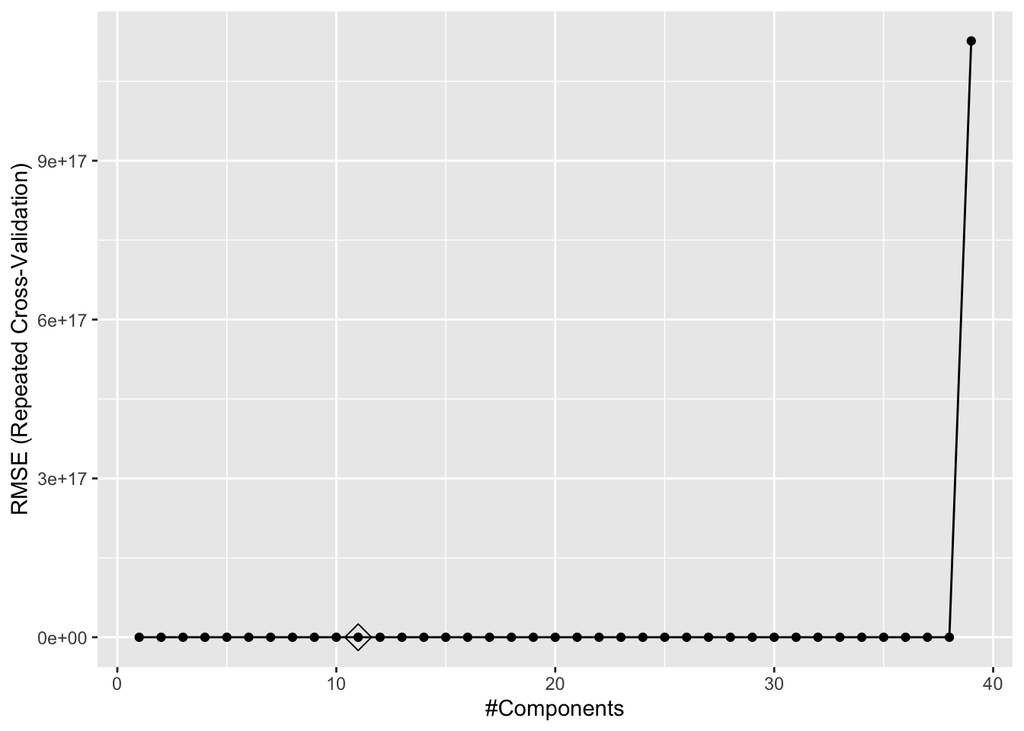

```r
ggplot(pls.fit, highlight = TRUE)
```

The test error is 21243.27, and 11 components are included in my model.

```r
set.seed(2)
pls.fit.onse <- train(x, y,
                 method = "pls",
                 tuneGrid = data.frame(ncomp = 1:39),
                 trControl = ctrl2,
                 preProcess = c("center", "scale"))
predy2.pls2.onse <- predict(pls.fit.onse, newdata = x_test)
sqrt(mean((y_test - predy2.pls2.onse)^2))
```

```
## [1] 20796.93
```

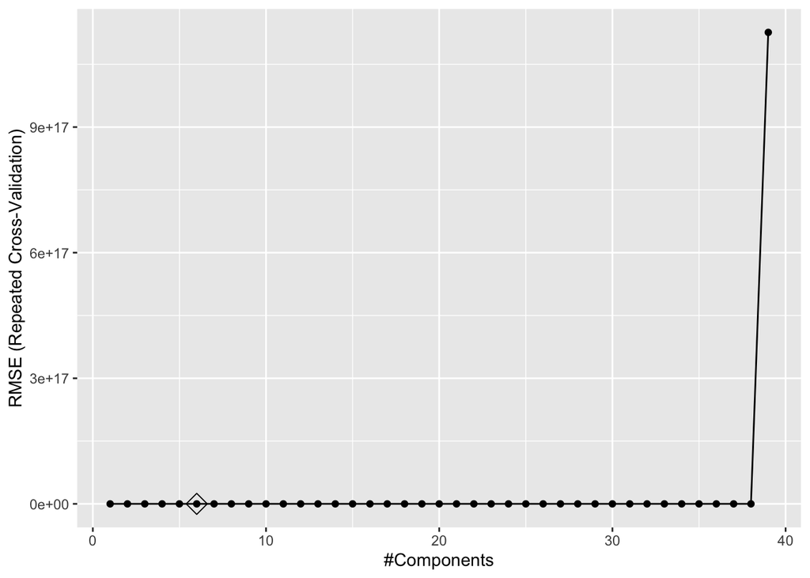

```r
ggplot(pls.fit.onse, highlight = TRUE)
```

When applying the 1se method, the test error is 20796.93, and 6 components are included in the model.

# (d) Choose the best model for predicting the response and explain your choice.

```r
resamp <- resamples(list(lasso=lasso.fit ,
                         lasso.1se=lasso.fit.onse,
                         elastic_net = elasticnet.fit,
                         elastic_net.1se=elasticnet.fit.1se,
                         pls=pls.fit,
                         pls.1se = pls.fit.onse))
summary(resamp)
```

```
##
## Call:
## summary.resamples(object = resamp)
##
## Models: lasso, lasso.1se, elastic_net, elastic_net.1se, pls, pls.1se
## Number of resamples: 50
##
## MAE
##                     Min.  1st Qu.   Median     Mean  3rd Qu.     Max. NA's
## lasso           14152.55 15644.65 16697.87 16641.30 17438.20 20886.86    0
## lasso.1se       14266.51 15609.07 16657.40 16626.43 17374.28 21314.31    0
## elastic_net     14165.55 15596.23 16672.14 16606.15 17395.72 20882.90    0
## elastic_net.1se 14004.81 15624.40 16723.50 16586.28 17396.60 21068.76    0
## pls             14022.76 15696.11 16734.02 16686.61 17486.46 20931.03    0
## pls.1se         13949.88 15688.30 16576.19 16575.93 17243.22 20932.60    0
##
## RMSE
##                     Min.  1st Qu.   Median     Mean  3rd Qu.     Max. NA's
## lasso           19593.87 21332.16 22508.92 22889.82 24365.93 28338.65    0
## lasso.1se       19297.44 21394.62 23145.89 23148.13 24792.10 29467.59    0
## elastic_net     19521.40 21349.28 22618.20 22882.17 24368.71 28377.86    0
## elastic_net.1se 18913.89 21476.16 23202.83 23148.69 24662.34 29027.90    0
## pls             19625.67 21393.49 22481.30 22887.00 24395.86 28462.45    0
## pls.1se         19295.71 21580.70 22738.21 23011.17 24554.18 28774.87    0
##
## Rsquared
##                      Min.   1st Qu.    Median      Mean   3rd Qu.      Max.
## lasso           0.8563187 0.8903257 0.9037082 0.9037353 0.9170771 0.9388831
## lasso.1se       0.8556182 0.8861005 0.9025398 0.9016389 0.9157162 0.9375494
## elastic_net     0.8565210 0.8903216 0.9036955 0.9038200 0.9176648 0.9386850
## elastic_net.1se 0.8571804 0.8868808 0.9013192 0.9021126 0.9146522 0.9362909
## pls             0.8553670 0.8909901 0.9036199 0.9037282 0.9180389 0.9399278
## pls.1se         0.8562480 0.8883904 0.9036064 0.9027338 0.9162808 0.9394765
##                 NA's
## lasso              0
## lasso.1se          0
## elastic_net        0
## elastic_net.1se    0
## pls                0
## pls.1se            0
```

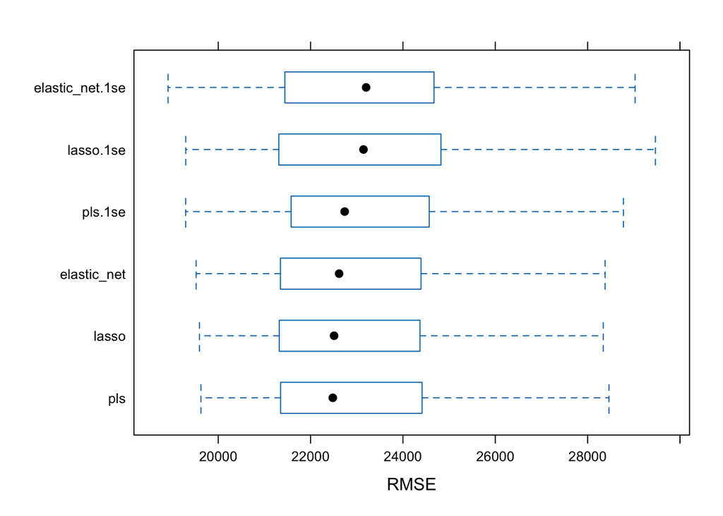

```r
bwplot(resamp, metric = "RMSE")
```

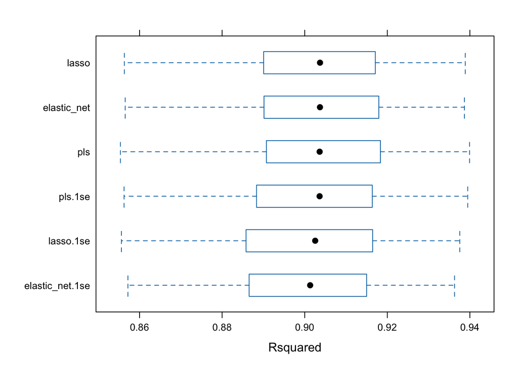

```r
bwplot(resamp, metric = "Rsquared")
```

# (e) If “caret” was used for the elastic net in (b), retrain this model with “tidymodels”, and vice versa. Compare the selected tuning parameters between the two software approaches. Should there be discrepancies in the chosen parameters, discuss potential reasons for these differences.

```r
set.seed(2)
cv_folds <- vfold_cv(training_data, v = 10, repeats = 5)

enet_spec <- linear_reg(penalty = tune(), mixture = tune()) %>%
  set_engine("glmnet") %>%
  set_mode("regression")

# enet_spec %>% extract_parameter_dials("mixture")

enet_grid_set <- parameters(penalty(range = c(-5,10), trans = log_trans()),
                            mixture(range = c(0, 1)))
enet_grid <- grid_regular(enet_grid_set, levels = c(100, 21))

enet_workflow <- workflow() %>%
  add_model(enet_spec) %>%
  add_formula(Sale_Price ~ .)


enet_tune <- tune_grid(
  enet_workflow,
  resamples = cv_folds,
  grid = enet_grid
)


enet_best <- select_best(enet_tune, metric = "rmse")

final_enet_spec <- enet_spec %>%
  update(penalty = enet_best$penalty, mixture = enet_best$mixture)

enet_fit <- fit(final_enet_spec, formula = Sale_Price ~ ., data = training_data)
```

```r
enet_best$penalty
```

```
## [1] 675.2963
```

```r
enet_best$mixture
```

```
## [1] 0.05
```

```r
enet_pred <- predict(enet_fit, new_data = testing_data)

# Calculate test RMSE
sqrt(mean((enet_pred[[1]] - testing_data$Sale_Price)^2))
```

```
## [1] 20918.91
```

```r
# Extract results and apply the 1SE rule
enet_results <- enet_tune %>% collect_metrics()

min_rmse <- min(enet_results$mean[enet_results$.metric == "rmse"])
min_rmse_se <- enet_results$std_err[enet_results$mean == min_rmse]

lambda_within_1se <- enet_results$penalty[enet_results$mean <= (min_rmse + min_rmse_se)]
lambda_1se <- max(lambda_within_1se)

lambda_1se
```

```
## [1] 22026.47
```

The selected lambda is 675.2963, and the selected mixture is 0.05. The Test Error is 20918.91. The lambda selected by the tydimodels(675.2963) is different from caret (580.3529). But the selected alpha is the same (both equal to 0.05). When applying 1SE rule, the selected lambda is 22026.47 by tidymodels, and the lambda selected by caret is 5632.81. The difference in selected tuning parameters suggests that the optimization process and the cross-validation strategy might vary between caret and tidymodels. Each package may have different defaults for handling data splitting, grid search strategies, or even in the underlying implementation of the glmnet function.